# Correct spillover

2022-08-12

# Spillover correction

**Original scripts:** *Vito Zanotelli*, **adapted/maintained by:** *Nils Eling*

This section highlights how to generate a spillover matrix from individually acquired single metal spots on an agarose slide. Each spot needs to be imaged as its own acquisition/ROI and individual .txt files containing the pixel intensities per spot need to be available. For complete details on the spillover correction approach, please refer to the original publication [@Chevrier2017].

**Spillover slide preparation:**

- Prepare 2% agarose in double distilled H$_2$O in a beaker and melt it in a microwave until well dissolved.
- Dip a blank superfrost plus glass microscope slide into the agarose and submerge it until the label.
- Remove the slide and prop it up against a support to allow the excess agarose to run off onto paper towels.
- Allow the slide to dry completely (at least 30 minutes).
- Retrieve all the antibody conjugates used in the panel for which the spillover matrix is to be generated and place them on ice.
- Arrange them in a known order (e.g. mass of the conjugated metal).
- Pipette 0.3 µl spots of 0.4% trypan blue dye into an array on the slide. Prepare one spot per antibody, and make sure the spots are well separated.
- Pipette 0.3 µl of each antibody conjugate (usually at 0.5 mg/ml) onto a unique blue spot, taking care to avoid different antibodies bleeding into each other. Note the exact location of each conjugate on the slide.
- Let the spots dry completely, at least 1 hour.

**Spillover slide acquisition:**

- Create a .jpeg or .png image of the slide using a mobile phone camera or flat-bed scanner.
- In the CyTOF software, create a new file and import the slide image into it.
- Create a panorama across all the spots to visualize their locations.
- Within each spot, create a region of interest (ROI) with a width of 200 pixels and a height of 10 pixels.
- Name each ROI with the mass and name of the metal conjugate contained in the spot, e.g “Ir193” or “Ho165”. This will be how each .txt file is named.
- Set the profiling type of each ROI to “Local”.
- Apply the antibody panel to all the ROIs. This panel should contain all (or more) of the isotopes in the panel, with the correct metal specified. For example: if the metal used is Barium 138, make sure this, rather than Lanthanum 138, is selected.
- Save the file, make sure “Generate Text File” is selected, and start the acquisition.

This procedure will generate an MCD file similar to the one available on zenodo: https://zenodo.org/record/5949116/files/compensation.zip

The original code of the spillover correction manuscript is available on Github [here](https://github.com/BodenmillerGroup/cyTOFcompensation); however, due to changes in the [CATALYST](https://bioconductor.org/packages/release/bioc/html/CATALYST.html) package, users were not able to reproduce the analysis using the newest software versions. The following workflow uses the newest package versions to generate a spillover matrix.

1. Reading in the data
2. Quality control
3. (Optional) pixel binning
4. “Debarcoding” for pixel assignment
5. Pixel selection for spillover matrix estimation
6. Spillover matrix generation
7. Saving the results
8. Single-cell compensation
9. Image compensation

## Generate the spillover matrix

In the first step, we will generate a spillover matrix based on the single-metal spots and save it for later use.

### Read in the data

Here, we will read in the individual .txt files into a `SingleCellExperiment` object. This object can be used directly by the `CATALYST` package to estimate the spillover.

For this to work, the .txt file names need to contain the spotted metal isotope name. By default, the first occurrence of the isotope in the format `(mt)(mass)` (e.g. `Sm152` for Samarium isotope with the atomic mass 152) will be used as spot identifier. Alternatively, a named list of already read-in pixel intensities can be provided. For more inforation, please refer to the man page `?readSCEfromTXT`.

For further downstream analysis, we will asinh-transform the data using a cofactor of 5; a common transformation for CyTOF data [@Bendall2011].

```r
library(imcRtools)
path <- "/mnt/Multimodal_Imaging_Daria/_Data_Analysis/_tmp_daria/Image_analysis/20220723_Steinbock_Mesmer_IFbased"
path_to_spillover_data <- "/mnt/Multimodal_Imaging_Daria/20220518_DL_SpilloverCorrection/Extra"

# Create SingleCellExperiment from .txt files
sce <- readSCEfromTXT(path_to_spillover_data)
```

```
## Spotted channels:  Y89, In115, La139, Nd142, Nd143, Nd144, Nd145, Nd146, Sm147, Nd148, Sm149, Nd150, Eu151, Sm152, Eu153, Sm154, Gd155, Gd156, Gd158, Tb159, Gd160, Dy161, Dy162, Dy163, Dy164, Ho165, Er166, Er167, Er168, Tm169, Er170, Yb171, Yb172, Yb173, Yb174, Lu175, Yb176, Ir191, Ir193, Pt196, …
## Acquired channels:  Y89, In115, Xe131, Xe134, Ba136, La139, Nd142, Nd143, Nd144, Nd145, Nd146, Sm147, Nd148, Sm149, Nd150, Eu151, Sm152, Eu153, Sm154, Gd155, Gd156, Gd158, Tb159, Gd160, Dy161, Dy162, Dy163, Dy164, Ho165, Er166, Er167, Er168, Tm169, Er170, Yb171, Yb172, Yb173, Yb174, Lu175, Yb176,…
## Channels spotted but not acquired:
## Channels acquired but not spotted:  Xe131, Xe134, Ba136
```

```r
assay(sce, "exprs") <- asinh(counts(sce)/5)
assay(sce, "exprs_cof1") <- asinh(counts(sce)/1)
```

### Quality control

In the next step, we will observe the median pixel intensities per spot and threshold on medians < 200 counts. These types of visualization serve two purposes:

1. Small median pixel intensities (< 200 counts) might hinder the robust estimation of the channel spillover. In that case, consecutive pixels can be summed (see Optional pixel binning).
2. Each spotted metal (row) should show the highest median pixel intensity in its corresponding channel (column). If this is not the case, either the naming of the .txt files was incorrect or the incorrect metal was spotted.

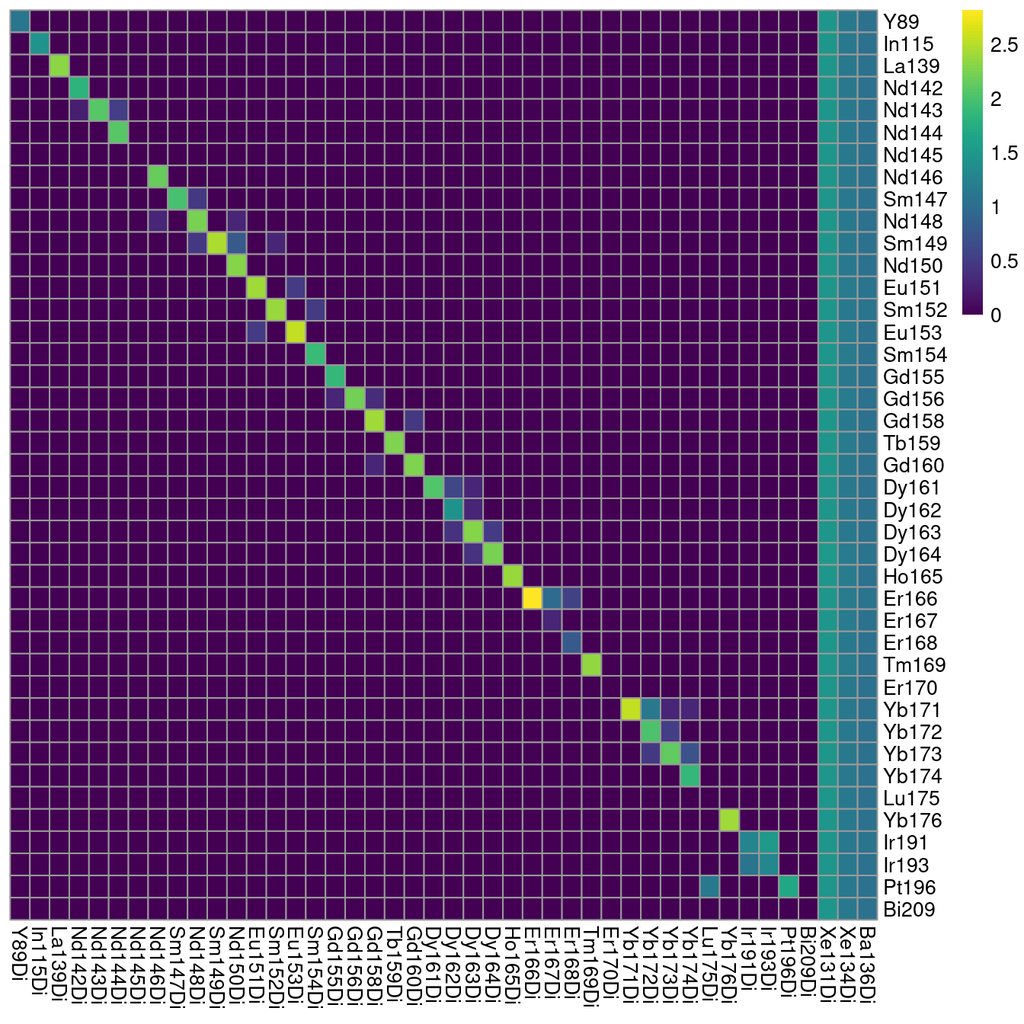

```r
# Log10 median pixel counts per spot and channel
plotSpotHeatmap(sce)
```

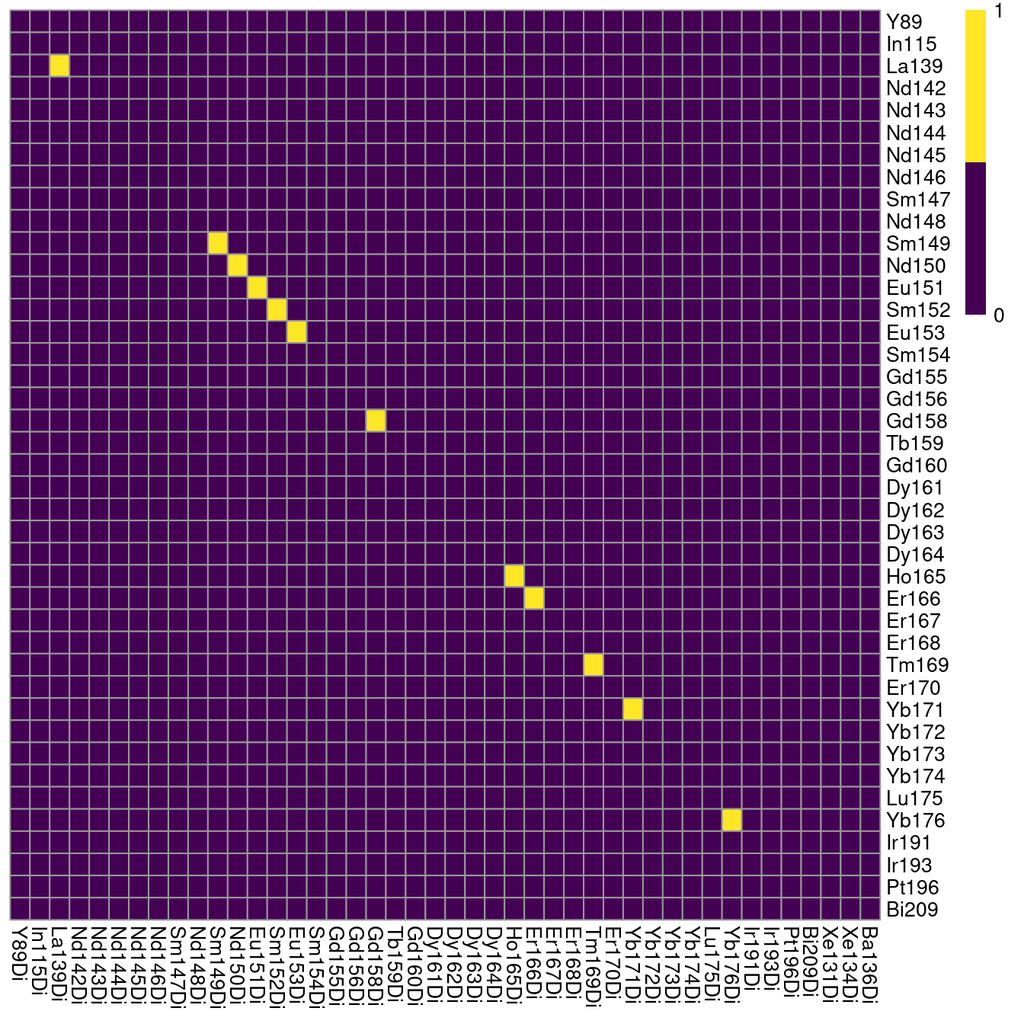

```r
# Thresholded on 200 pixel counts
plotSpotHeatmap(sce, log = FALSE, threshold = 200)
```

### Optional pixel binning

In cases where median pixel intensities are low (< 200 counts), consecutive pixels can be summed to increase the robustness of the spillover estimation. The `imcRtools` package provides the `binAcrossPixels` function, which performs aggregation for each channel across `bin_size` consecutive pixels per spotted metal.

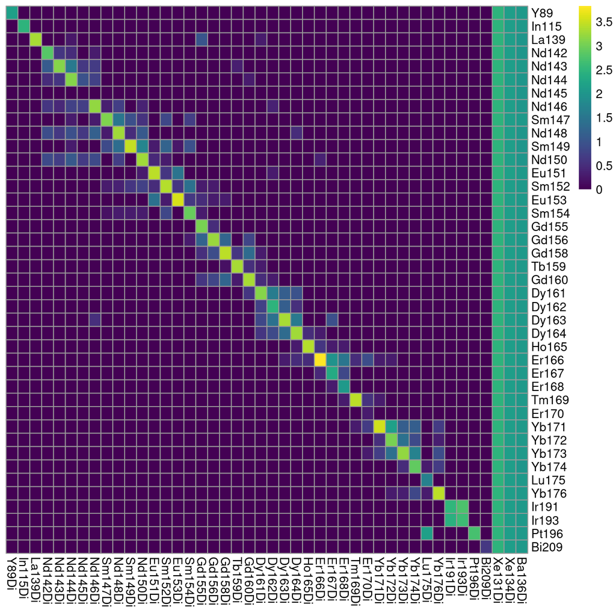

```r
# Define grouping
bin_size = 10

sce2 <- binAcrossPixels(sce, bin_size = bin_size)

# Log10 median pixel counts per spot and channel
plotSpotHeatmap(sce2)
```

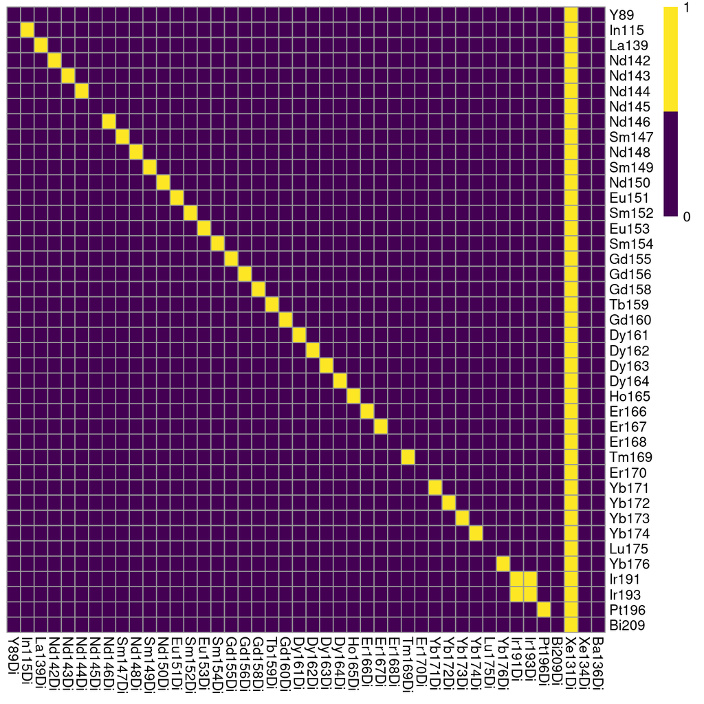

```r
# Thresholded on 200 pixel counts
plotSpotHeatmap(sce2, log = FALSE, threshold = 200)
```

```r
sum(counts(sce[2,sce$sample_mass=="145"])) #channel 145 is zero, find out why
```

```
## [1] 0
```

### Filtering incorrectly assigned pixels

The following step uses functions provided by the `CATALYST` package to “debarcode” the pixels. Based on the intensity distribution of all channel, pixels are assigned to their corresponding barcode; here this is the already known metal spot. This procedure serves the purpose to identify pixels that cannot be robustly assigned to the spotted metal. Pixels of such kind can be regarded as “noisy”, “background” or “artefacts” that should be removed prior to spillover estimation.

We will also need to specify which channels were spotted (argument `bc_key`). This information is directly contained in the `colData(sce)` slot. To facilitate visualization, we will order the `bc_key` by mass.

The general workflow for pixel debarcoding is as follows:

1. assign a preliminary metal mass to each pixel
2. for each pixel, estimate a cutoff parameter for the distance between positive and negative pixel sets
3. apply the estimated cutoffs to identify truly positive pixels

```r
library(CATALYST)

bc_key <- as.numeric(unique(sce$sample_mass))
bc_key <- bc_key[order(bc_key)]

sce <- assignPrelim(sce, bc_key = bc_key)
sce <- estCutoffs(sce)
sce <- applyCutoffs(sce)
```

The obtained `SingleCellExperiment` now contains the additional `bc_id` entry. For each pixel, this vector indicates the assigned mass (e.g. `161`) or `0`, meaning unassigned.

This information can be visualized in form of a heatmap:

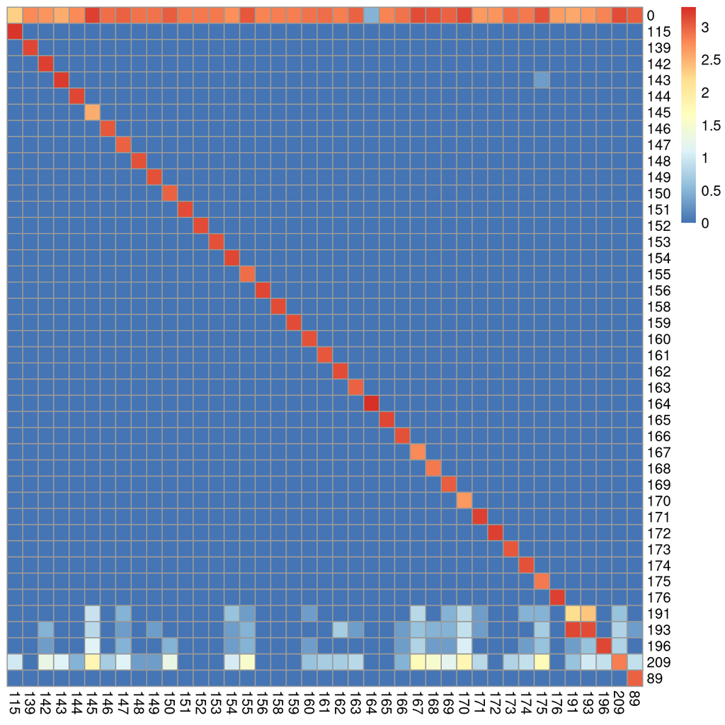

```r
library(pheatmap)
cur_table <- table(sce$bc_id, sce$sample_mass)

pheatmap(log10(cur_table + 1),
         cluster_rows = FALSE,
         cluster_cols = FALSE)
```

However, in cases where incorrect assignment occurred or where few pixels were measured for some spots, the `imcRtools` package exports a simple helper function to exclude pixels based on these criteria:

```r
sce <- filterPixels(sce, minevents = 40, correct_pixels = TRUE)
```

### Compute spillover matrix

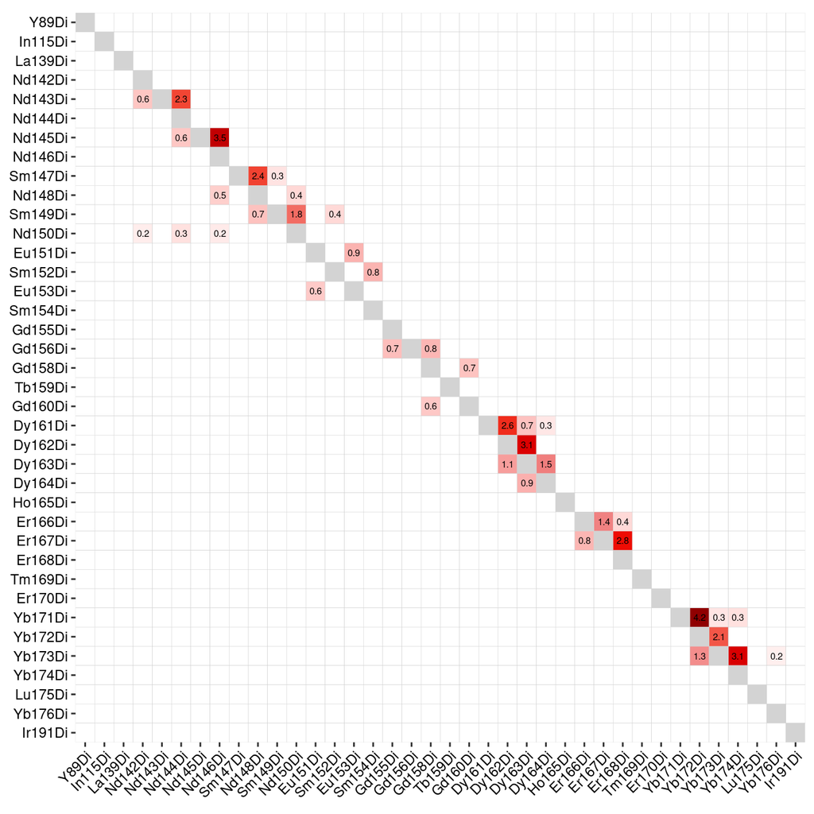

```r
sce <- computeSpillmat(sce)

isotope_list <- CATALYST::isotope_list
isotope_list$Ar <- 80

plotSpillmat(sce, isotope_list = isotope_list)
```

Here, we will save the spillover matrix as .csv.

### Save spillover matrix as csv

Next, we will write out the spillover matrix as .csv file for possible later use.

```r
sm <- metadata(sce)$spillover_matrix
write.csv(sm, file.path(path,"data/spillover_matrix.csv"))
```

## Single-cell data compensation

Non-metal columns present in the SPE (single-cell data), but not in the SCE (spillover matrix) will be added such that they do neither receive nor cause spill, as explained [here](https://rdrr.io/bioc/CATALYST/man/compCytof.html).

```r
spe <- readRDS(file.path(path,"data/spe.rds"))
rowData(spe)$channel_name <- paste0(rowData(spe)$channel, "Di")

spe <- compCytof(spe, sm,
                 transform = TRUE, cofactor = 1,
                 isotope_list = isotope_list,
                 overwrite = FALSE)
```

To check the effect of channel spillover compensation, the expression of markers that are affected by spillover (e.g., HLA-DR in channel Nd143 and PRPH in channel Nd144) can be visualized in form of scatter plots before and after compensation.

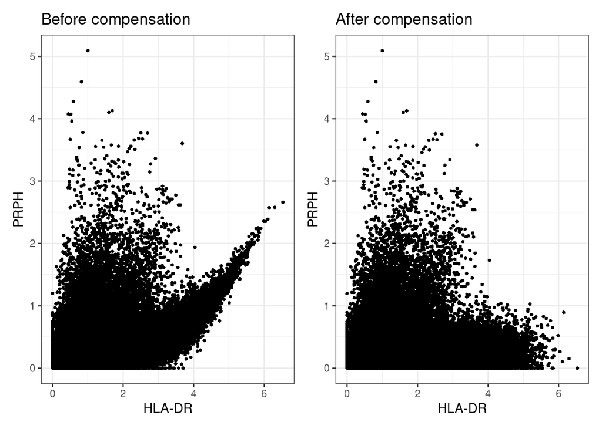

```r
library(dittoSeq)
library(patchwork)
before <- dittoScatterPlot(spe, x.var = "HLA-DR", y.var = "PRPH",
                           assay.x = "exprs", assay.y = "exprs") +
    ggtitle("Before compensation")

after <- dittoScatterPlot(spe, x.var = "HLA-DR", y.var = "PRPH",
                          assay.x = "compexprs", assay.y = "compexprs") +
    ggtitle("After compensation")
before + after
```

We observe that the spillover Nd43 –> Nd144 was successfully corrected. Optionally, the compensated counts can be transferred to the counts slot. We will not perform this step, as we want to have the option to choose between non- and compensated counts/exprs.

```r
#assay(spe, "counts") <- assay(spe, "compcounts")
#assay(spe, "exprs") <- assay(spe, "compexprs")
#assay(spe, "compcounts") <- assay(spe, "compexprs") <- NULL
```

## Save objects

For further downstream analysis, the compensated `SpatialExperiment` are saved:

```r
saveRDS(spe, file.path(path,"data/spe.rds"))
```